# **Hito 3.** Análisis de canciones: Lo que suena vs. lo que dice

## Proyecto Minería de Datos.

Integrantes (grupo 2):

- Benjamín Aguilar.
- Benjamín Alvial.
- Diego Carmona.
- Jules Fredes C.
- Diego Reyes.

## 1. Introducción

La música es una vía de expresión del ser humano y nunca ha dejado de estar presente, pero la forma de su distribución sí ha cambiado. El mercado mundial de los servicios de *streaming* de música ha crecido muchísimo en los últimos años, y representan una proporción cada vez mayor del mercado de música en general. Por lo tanto, da abundante espacio al estudio y análisis de la música, ya que se puede estudiar el objeto como tal, además de la teoría ya existente, más aún cuando los servicios de *streaming* optan por integrar funcionalidades automatizadas en sus aplicaciones.

Además, el ser humano se dedica a clasificar todo lo que existe, incluyendo la música. Por ello, es interesante estudiar la categorización que el mismo ser humano ha creado - el género. Es común pensar que las canciones se definen en términos de género por la forma en que suenan más que de lo que hablan. Por lo tanto, se puede estudiar si esta hipótesis es certera, analizando aspectos técnicos para el sonido (lo que suena) y las letras (lo que dicen) de las canciones para los temas de los que tratan.

La utilidad del estudio de la clasificación de las canciones recae en los algoritmos de recomendación, pues el programador de estos debe decidir qué criterios utilizar para ver si dos canciones son similares. A su vez, estos pueden ser útiles para distintos propósitos:

- Generación automática de listas de reproducción.
- Complementar el desarrollo de aplicaciones que detectan canciones a partir de un segmento de audio.
- Encontrar canciones similares a otras para integrar la banda sonora en una película o serie.

## 2. Exploración de datos

### Sobre el conjunto de datos

Los datos a estudiar comprenden canciones creadas de los últimos setenta años y que están presentes en la plataforma de reproducción de música Spotify.

El conjunto de datos se encuentra disponible en: https://www.kaggle.com/datasets/saurabhshahane/music-dataset-1950-to-2019

```python
import pandas as pd
import warnings
warnings.filterwarnings("ignore")
df = pd.read_csv(r'C:\Users\benja\Desktop\Mineria de Datos\Hito 1\datos.csv')
df_real = df[['Unnamed: 0', 'track_name', 'release_date', 'genre', 'lyrics', 'len', 'danceability', 'loudness', 'acousticness', 'instrumentalness', 'valence', 'energy']]
```

El conjunto de datos, filtrado para el propósito del proyecto, tiene un total de 28.372 canciones, desde el 1950 al 2019. Cada canción tiene atributos técnicos y además atributos que representan emocionalidad, como las letras de las canciones. No hay valores nulos.

- Atributos que representan lo que suena o aspectos técnicos, de tipo numérico: 'danceability' (bailiabilidad), 'volumen' (volumen), 'acousticness' (acústica), 'instrumentalness' (instrumentalidad), 'valence' (valencia), 'energy' (energía).
- Atributo que representan lo que dice o aspecto emocional, de tipo string: 'lyrics' (letra).

Además, hay otras variables como 'genre' (género), 'track_name' (nombre), 'release_date' (año), entre otras.

```python
df_real.shape
```

```
(28372, 12)
```

```python
df_real.info()
```

```
<class 'pandas.core.frame.DataFrame'>
RangeIndex: 28372 entries, 0 to 28371
Data columns (total 12 columns):
 #   Column            Non-Null Count  Dtype
---  ------            --------------  -----
 0   Unnamed: 0        28372 non-null  int64
 1   track_name        28372 non-null  object
 2   release_date      28372 non-null  int64
 3   genre             28372 non-null  object
 4   lyrics            28372 non-null  object
 5   len               28372 non-null  int64
 6   danceability      28372 non-null  float64
 7   loudness          28372 non-null  float64
 8   acousticness      28372 non-null  float64
 9   instrumentalness  28372 non-null  float64
 10  valence           28372 non-null  float64
 11  energy            28372 non-null  float64
dtypes: float64(6), int64(3), object(3)
memory usage: 2.6+ MB
```

Se pueden observar algunos ejemplos de cómo son los aspectos que representan una canción.

```python
df_real.head()
```

|  | Unnamed: 0 | track_name | release_date | genre | lyrics | len | danceability | loudness | acousticness | instrumentalness | valence | energy |
| --- | --- | --- | --- | --- | --- | --- | --- | --- | --- | --- | --- | --- |
| 0 | 0 | mohabbat bhi jhoothi | 1950 | pop | hold time feel break feel untrue convince spea... | 95 | 0.357739 | 0.454119 | 0.997992 | 0.901822 | 0.339448 | 0.137110 |
| 1 | 4 | i believe | 1950 | pop | believe drop rain fall grow believe darkest ni... | 51 | 0.331745 | 0.647540 | 0.954819 | 0.000002 | 0.325021 | 0.263240 |
| 2 | 6 | cry | 1950 | pop | sweetheart send letter goodbye secret feel bet... | 24 | 0.456298 | 0.585288 | 0.840361 | 0.000000 | 0.351814 | 0.139112 |
| 3 | 10 | patricia | 1950 | pop | kiss lips want stroll charm mambo chacha merin... | 54 | 0.686992 | 0.744404 | 0.083935 | 0.199393 | 0.775350 | 0.743736 |
| 4 | 12 | apopse eida oneiro | 1950 | pop | till darling till matter know till dream live ... | 48 | 0.291671 | 0.646489 | 0.975904 | 0.000246 | 0.597073 | 0.394375 |

Además, se puede ver que las 10 palabras más comunes en las letras, independiente del género, son las siguientes.

```python
print(pd.Series(' '.join(df_real['lyrics']).split()).value_counts()[:10])
letras = df_real['lyrics']
```

```
know     33526
like     29649
time     26504
come     23619
go       17032
feel     16795
yeah     16787
away     16773
heart    16737
life     15906
dtype: int64
```

### Análisis de género

La principal variable a analizar es, como se mencionó en la introducción, el género, que es la forma en que se clasifican las canciones. La distribución de las canciones por género es como se muestra a continuación. Es algo que se debe tener en cuenta, pues las clases no están del todo balanceadas.

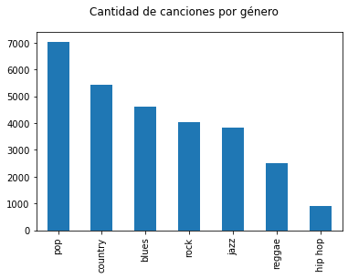

```python
import matplotlib.pyplot as plt
fig, ax = plt.subplots()
df_real['genre'].value_counts().plot(ax=ax, kind='bar')
fig.suptitle("Cantidad de canciones por género")
```

Además se pueden observar correlaciones entre distintos de estos aspectos técnicos. Por ejemplo, a medida que aumenta la energía, aumenta el volumen, que es una relación lógica y esperada.

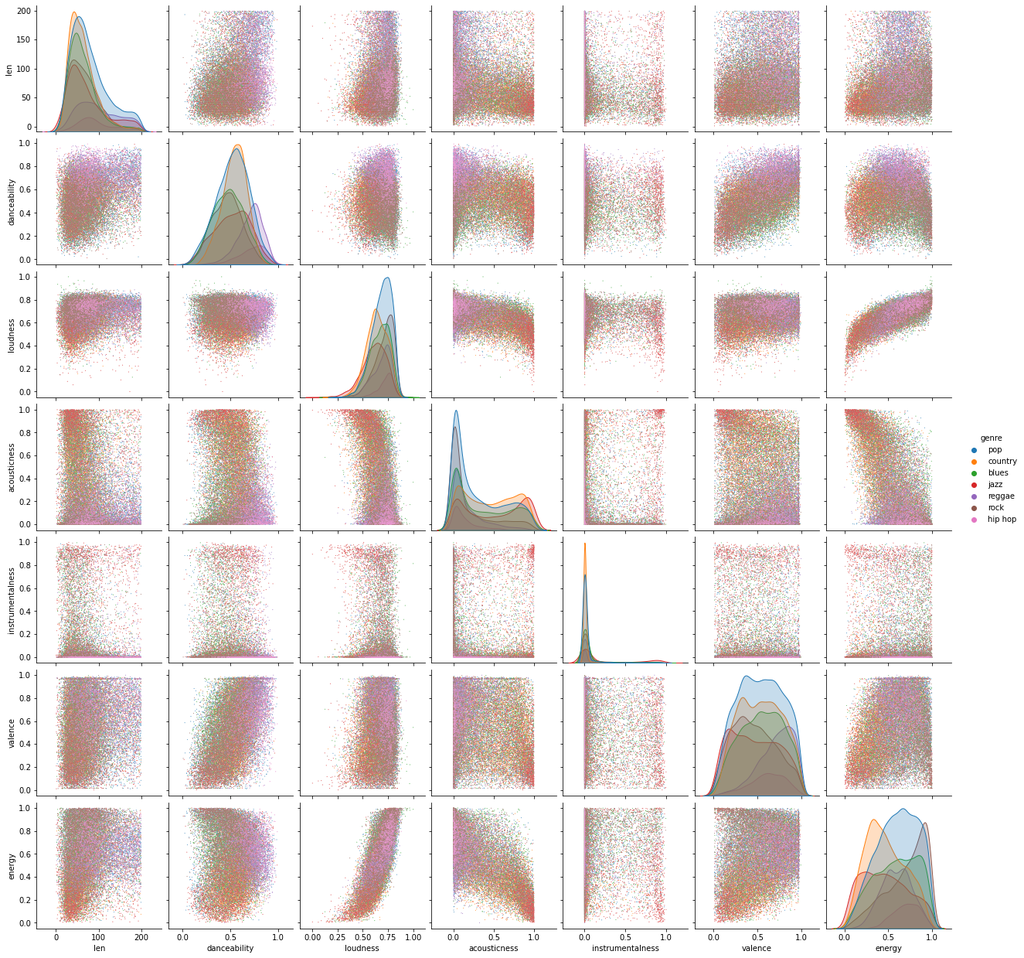

```python
import seaborn as sns
sns.pairplot(df_real, vars=['len', 'danceability', 'loudness', 'acousticness', 'instrumentalness', 'valence', 'energy'], hue='genre', plot_kws={"s": 1})
```

Se pueden ver las palabras más comunes por género. A priori es difícil encontrar palabras muy distintivas, salvo en casos como el hip hop. Nuevamente, es posible que la incorporación de frecuencias de palabras, y no solo las más comunes, permitan encontrar relaciones interesantes.

```python
for i in df_real.genre.unique():
  print(i, '...')
  copy = df_real[(df_real.genre==i)]
  print(pd.Series(' '.join(copy['lyrics']).split()).value_counts()[:5])
  print('--')
```

```
pop ...
know    9983
like    8349
time    6982
come    6304
yeah    5365
dtype: int64
--
country ...
know     5836
time     5230
like     4569
heart    4460
come     3900
dtype: int64
--
blues ...
know    4959
time    3945
like    3699
come    3677
baby    3382
dtype: int64
--
jazz ...
like    4017
know    3931
time    3470
come    2936
life    2217
dtype: int64
--
reggae ...
like    3790
know    3577
come    2951
time    2830
yeah    2492
dtype: int64
--
rock ...
know    3878
time    3471
like    3094
come    3036
away    2936
dtype: int64
--
hip hop ...
like     2131
know     1362
come      815
cause     799
nigga     776
dtype: int64
--
```

## 3. Preguntas y problemas

Un sistema de recomendación es un algoritmo, y debe entonces el programador considerar ciertos parámetros para tomar decisiones sobre qué tanto se parecen dos canciones. Luego, es natural preguntarse cuáles son esos parámetros. Una opción puede ser considerar los atributos técnicos (lo que suena), como bailabilidad, acústica, instrumentalidad, entre otros. Otra opción puede ser considerar la letra de una canción (lo que dice). Se hipotetiza que la primera opción es la que arroja resultados más certeros para identificar similitudes entre canciones. En este proyecto se busca estudiar si efectivamente es más lógico comparar canciones por cómo suenan que por lo que dicen, para efectos de la programación de un algoritmo de recomendación.

Con esto nacen las preguntas:

1. ¿Los aspectos técnicos de una canción son determinantes en su género?
2. ¿La letra de una canción es determinante en su género?

Para ello, es de interés estudiar la clasificación natural que el ser humano genera para las canciones, que sería el género. De esta forma, sería útil estudiar el atributo género, a modo de saber si es más fácil clasificar una canción por sus atributos técnicos o por su letra.

Por lo anterior, se busca responder la pregunta con técnicas de Minería de Datos.

- Problema de clasificación 1: Generar un modelo (I) que pueda predecir el género de una canción basándose en los aspectos técnicos como bailabilidad, volumen, energía, entre otros.
- Problema de clasificación 2: Generar un modelo (II) que pueda predecir el género de una canción basándose en las palabras contenidas en la letra de ella.

Asimismo, sería interesante conocer si lo que llamamos género efectivamente tiene una relación matemática con los aspectos técnicos de las canciones. Es decir, si efectivamente lo que percibimos como pop, jazz, rock tienen aspectos técnicos que los distinguen unos de otros.

Con ello nace la pregunta:

1. ¿Las canciones se agrupan de forma natural en los géneros que conocemos, considerando sus aspectos técnicos, como bailabilidad, volumen, energía, entre otros?
- Problema de clustering: Generar un modelo (III) que pueda agrupar las canciones a partir de los aspectos técnicos como bailabilidad, volumen, energía, entre otros.

Dados los problemas y preguntas planteadas, se tiene que las preguntas principales que guían todo el proyecto son: ¿El género de una canción está más ligado al sonido (lo que suena) o a la verbalización (lo que dice) de una canción? ¿La programación de un algoritmo de recomendación debiese considerar la letra (lo que dice) o aspectos técnicos (lo que suena) para considerar canciones como similares?

Luego, se puede comparar el éxito de los modelos de clasificación y aproximarse a responder cuál de los dos es más determinante para clasificar un género, que se justifica si el modelo de clustering arroja resultados positivos.

Si el modelo (I) tiene un mejor desempeño que el modelo (II), se podría confirmar la hipótesis de que los atributos técnicos son más decisivos a la hora de clasificar una canción. Por lo tanto, se concluiría que estos son los atributos que un programador de un sistema de recomendación debiese tomar en consideración con mayor importancia.

## 4. Propuesta experimental

Para la primera propuesta experimental, se debe generar un modelo de clasificador de géneros basado en aspectos técnicos de las canciones, donde los pasos a seguir serán lo siguientes:

1. Aplicar técnicas de subsampling u oversampling para lograr un balance de los géneros de las canciones.
2. Generar modelos de clasificación con SVC, Decision Tree y KNN, usando un modelo de entrenamiento 25/75. Para KNN y Decision Tree se necesitarán encontrar los hiperparámetros óptimos y para esto se aplicará GridSearchCV.
3. Evaluar los modelos mediante distintos parámetros evaluativos, siendo estos precision, recall y f1-score.
4. Comparar desempeño de los modelos y concluir si el mejor modelo tiene un buen desempeño para responder la pregunta planteada. Vale decir, ver si el modelo clasifica las canciones de forma correcta tomando sus aspectos técnicos como base.

Para la segunda propuesta experimental, se debe generar un modelo de clasificador de géneros basado en las letras de las canciones, donde los pasos a seguir serán lo siguientes:

1. Convertir las letras de las canciones en información numérica.
2. Aplicar técnicas de balanceamiento de datos.
3. Generar modelos de clasificación con Decision Tree, KNN y SVC, usando un modelo de entrenamiento 25/75.
4. Evaluar los modelos mediante distintos parámetros evaluativos, siendo estos precision, recall y f1-score.
5. Comparar desempeño de los modelos y concluir si el mejor modelo tiene un buen desempeño para responder la pregunta planteada. Vale decir, ver si el modelo clasifica las canciones de forma correcta tomando su letra como base.

Para la tercera propuesta experimental, se debe generar un modelo de clustering y evaluarlo con una medida externa, que correspondería a las etiquetas conocidas de género. Por lo tanto, los pasos a seguir son:

1. Generar modelos de clustering con K-Means, DBSCAN y clustering aglomerativo, usando cantidad de clusters = 7, que corresponde a la cantidad de géneros.
2. Graficar representación PCA original de la data y comparar con la distribución PCA de los clusters de los modelos (visualmente).
3. Evaluar cada uno de los modelos con medida externa ("opinión experta"), utilizando la etiqueta de género conocida.
4. Comparar desempeños y concluir si el mejor modelo tiene un buen desempeño para responder la pregunta planteada. Vale decir, ver si el modelo predice que las canciones efectivamente son de su género etiquetado a partir del cluster asignado. Se estima que 70% de correctas calificaciones puede considerarse una buena proporción.

## 5. Resultados preliminares

### Primera propuesta

Se crea el dataframe. Los datos afortunadamente ya vienen en su forma normalizada.

```python
df_tecnico = df[['genre', 'danceability', 'loudness', 'acousticness', 'instrumentalness', 'valence', 'energy']]
df_tecnico.head()
```

|  | genre | danceability | loudness | acousticness | instrumentalness | valence | energy |
| --- | --- | --- | --- | --- | --- | --- | --- |
| 0 | pop | 0.357739 | 0.454119 | 0.997992 | 0.901822 | 0.339448 | 0.137110 |
| 1 | pop | 0.331745 | 0.647540 | 0.954819 | 0.000002 | 0.325021 | 0.263240 |
| 2 | pop | 0.456298 | 0.585288 | 0.840361 | 0.000000 | 0.351814 | 0.139112 |
| 3 | pop | 0.686992 | 0.744404 | 0.083935 | 0.199393 | 0.775350 | 0.743736 |
| 4 | pop | 0.291671 | 0.646489 | 0.975904 | 0.000246 | 0.597073 | 0.394375 |

Se separan los datos en conjuntos de evaluación y entrenamiento, en una proporcion 25/75.

```python
from sklearn.model_selection import train_test_split

y = df_tecnico['genre'].values
X_train, X_test, y_train, y_test = train_test_split(df_tecnico, y, test_size=0.25, stratify=y)
```

Se observa nuevamente el desbalance de los datos bajo los que se quiere entrenar.

```python
import numpy as np
np.unique(y_train,return_counts=True)
```

```
(array(['blues', 'country', 'hip hop', 'jazz', 'pop', 'reggae', 'rock'],
       dtype=object),
 array([3453, 4084,  678, 2884, 5281, 1874, 3025], dtype=int64))
```

Se aplican técnicas de subsampling y de oversampling al conjunto de entrenamiento, para poder intentar generar modelos con ambas y ver cuál es la mejor.

```python
#oversampling sobre el grupo de training
X_train = X_train.reset_index(drop=True)
idx = np.random.choice(X_train[X_train['genre'] == "country"].index, size=1197)
data_oversampled = pd.concat([X_train, X_train.iloc[idx]])

idx = np.random.choice(X_train[X_train['genre'] == "blues"].index, size=1828)
data_oversampled = pd.concat([data_oversampled, X_train.iloc[idx]])

idx = np.random.choice(X_train[X_train['genre'] == "rock"].index, size=2256)
data_oversampled = pd.concat([data_oversampled, X_train.iloc[idx]])

idx = np.random.choice(X_train[X_train['genre'] == "jazz"].index, size=2397)
data_oversampled = pd.concat([data_oversampled, X_train.iloc[idx]])

idx = np.random.choice(X_train[X_train['genre'] == "reggae"].index, size=3407)
data_oversampled = pd.concat([data_oversampled, X_train.iloc[idx]])

idx = np.random.choice(X_train[X_train['genre'] == "hip hop"].index, size=4603)
data_oversampled = pd.concat([data_oversampled, X_train.iloc[idx]])

print("Data oversampled on genre`s classes")
print(data_oversampled['genre'].value_counts())
print()


#subsampling sobre el grupo de training
idx = np.random.choice(X_train.loc[X_train.genre == "pop"].index, size=4603, replace=False)
data_subsampled = X_train.drop(X_train.iloc[idx].index)

idx = np.random.choice(X_train.loc[X_train.genre == "country"].index, size=3406, replace=False)
data_subsampled = data_subsampled.drop(X_train.iloc[idx].index)

idx = np.random.choice(X_train.loc[X_train.genre == "blues"].index, size=2775, replace=False)
data_subsampled = data_subsampled.drop(X_train.iloc[idx].index)

idx = np.random.choice(X_train.loc[X_train.genre == "rock"].index, size=2347, replace=False)
data_subsampled = data_subsampled.drop(X_train.iloc[idx].index)

idx = np.random.choice(X_train.loc[X_train.genre == "jazz"].index, size=2206, replace=False)
data_subsampled = data_subsampled.drop(X_train.iloc[idx].index)

idx = np.random.choice(X_train.loc[X_train.genre == "reggae"].index, size=1196, replace=False)
data_subsampled = data_subsampled.drop(X_train.iloc[idx].index)
print("Data subsampled on genre`s classes")
print(data_subsampled['genre'].value_counts())
```

```
Data oversampled on genre`s classes
country    5281
rock       5281
pop        5281
reggae     5281
blues      5281
jazz       5281
hip hop    5281
Name: genre, dtype: int64

Data subsampled on genre`s classes
country    678
pop        678
reggae     678
rock       678
jazz       678
hip hop    678
blues      678
Name: genre, dtype: int64
```

Se generan los conjuntos de entrenamiento finales.

```python
# datos para testing
X_test = X_test[X_test.columns.difference(["genre"])].values
y_test = y_test

# datos entrenamiento "originales"
X_train = X_train[X_train.columns.difference(["genre"])].values
y_train = y_train

df_tecnico[df_tecnico.columns.difference(['genre'])].values
# datos entrenamiento "oversampleados"
X_over = data_oversampled[data_oversampled.columns.difference(["genre"])].values
y_over = data_oversampled["genre"].values

# datos entrenamiento "subsampleados"
X_subs = data_subsampled[data_subsampled.columns.difference(["genre"])].values
y_subs = data_subsampled["genre"].values
```

Ahora se aplicaran 3 modelos de clasificacion a los datos seleccionados, SVC, K Nearest Neighbors y Decision Tree. Para estos dos últimos dos se ocupa GridSearchCV con el fin de encontrar los hiperparámetros óptimos para estos modelos.

### Modelo SVC

Se genera el modelo con data original, under y oversampling.

```python
from sklearn.svm import SVC
#Comparacion de modelos de SVC

#Original data
clf_SVC_o=SVC()
clf_SVC_o.fit(X_train, y_train)
y_pred_SVC_o = clf_SVC_o.predict(X_test)

#Subsampled data
clf_SVC_sub=SVC()
clf_SVC_sub.fit(X_subs, y_subs)
y_pred_SVC_sub = clf_SVC_sub.predict(X_test)

#Oversampled data
clf_SVC_over=SVC()
clf_SVC_over.fit(X_over, y_over)
y_pred_SVC_over = clf_SVC_over.predict(X_test)
```

Se obtienen los siguientes resultados:

```python
#Resultados
from sklearn.metrics import classification_report
print("SVC models: ")
print("Original data:")
print(classification_report(y_test, y_pred_SVC_o))
print("Subsample Data:")
print(classification_report(y_test, y_pred_SVC_sub))
print("Oversample Data:")
print(classification_report(y_test, y_pred_SVC_over))
```

```
SVC models:
Original data:
              precision    recall  f1-score   support

       blues       0.43      0.09      0.15      1151
     country       0.38      0.49      0.42      1361
     hip hop       0.67      0.01      0.02       226
        jazz       0.51      0.32      0.39       961
         pop       0.32      0.58      0.41      1761
      reggae       0.46      0.37      0.41       624
        rock       0.42      0.32      0.36      1009

    accuracy                           0.37      7093
   macro avg       0.45      0.31      0.31      7093
weighted avg       0.41      0.37      0.35      7093

Subsample Data:
              precision    recall  f1-score   support

       blues       0.30      0.19      0.23      1151
     country       0.37      0.51      0.43      1361
     hip hop       0.16      0.64      0.25       226
        jazz       0.42      0.38      0.40       961
         pop       0.33      0.06      0.11      1761
      reggae       0.32      0.48      0.39       624
        rock       0.34      0.49      0.40      1009

    accuracy                           0.33      7093
   macro avg       0.32      0.39      0.32      7093
weighted avg       0.34      0.33      0.30      7093

Oversample Data:
              precision    recall  f1-score   support

       blues       0.33      0.20      0.25      1151
     country       0.37      0.56      0.45      1361
     hip hop       0.17      0.63      0.27       226
        jazz       0.44      0.39      0.41       961
         pop       0.38      0.07      0.12      1761
      reggae       0.34      0.49      0.40       624
        rock       0.35      0.49      0.41      1009

    accuracy                           0.34      7093
   macro avg       0.34      0.41      0.33      7093
weighted avg       0.36      0.34      0.31      7093
```

### K Nearest Neighbors

Se genera el modelo con data original, under y oversampling.

```python
from sklearn.model_selection import GridSearchCV
from sklearn.metrics import classification_report
from sklearn.neighbors import KNeighborsClassifier

#KNN parameters
tuned_parameters = {'n_neighbors': [ 2, 3, 4, 5, 10],
                    'weights': ['uniform','distance']}
score = 'precision'

#KNN Original values
clf_kmeans_o = GridSearchCV(KNeighborsClassifier(),
                   param_grid=tuned_parameters,
                   cv=5,
                   scoring=score)
clf_kmeans_o.fit(X_train, y_train)
y_pred_kmeans_o = clf_kmeans_o.predict(X_test)


#KNN Subsampled values
clf_kmeans_s = GridSearchCV(KNeighborsClassifier(),
                   param_grid=tuned_parameters,
                   cv=5,
                   scoring=score)
clf_kmeans_s.fit(X_subs, y_subs)
y_pred_kmeans_s = clf_kmeans_s.predict(X_test)

#KNN Oversampled values
clf_kmeans_over = GridSearchCV(KNeighborsClassifier(),
                   param_grid=tuned_parameters,
                   cv=5,
                   scoring=score)
clf_kmeans_over.fit(X_over, y_over)
y_pred_kmeans_over = clf_kmeans_over.predict(X_test)
```

Se obtienen los siguientes resultados:

```python
#Resultados
print("Mejor combinación de parámetros:")
print(clf_kmeans_over.best_params_)
print("KMeans models: ")
print("Original data:")
print(classification_report(y_test, y_pred_kmeans_o))
print("Subsample Data:")
print(classification_report(y_test, y_pred_kmeans_s))
print("Oversample Data:")
print(classification_report(y_test, y_pred_kmeans_over))
```

```
Mejor combinación de parámetros:
{'n_neighbors': 2, 'weights': 'uniform'}
KMeans models:
Original data:
              precision    recall  f1-score   support

       blues       0.21      0.38      0.27      1151
     country       0.29      0.41      0.34      1361
     hip hop       0.19      0.25      0.21       226
        jazz       0.30      0.29      0.29       961
         pop       0.31      0.23      0.26      1761
      reggae       0.33      0.15      0.21       624
        rock       0.34      0.09      0.14      1009

    accuracy                           0.27      7093
   macro avg       0.28      0.26      0.25      7093
weighted avg       0.29      0.27      0.26      7093

Subsample Data:
              precision    recall  f1-score   support

       blues       0.20      0.35      0.25      1151
     country       0.28      0.35      0.31      1361
     hip hop       0.13      0.53      0.21       226
        jazz       0.28      0.29      0.28       961
         pop       0.30      0.14      0.19      1761
      reggae       0.31      0.20      0.24       624
        rock       0.31      0.08      0.13      1009

    accuracy                           0.24      7093
   macro avg       0.26      0.28      0.23      7093
weighted avg       0.27      0.24      0.23      7093

Oversample Data:
              precision    recall  f1-score   support

       blues       0.21      0.32      0.26      1151
     country       0.30      0.37      0.33      1361
     hip hop       0.16      0.20      0.18       226
        jazz       0.29      0.32      0.30       961
         pop       0.30      0.18      0.23      1761
      reggae       0.29      0.29      0.29       624
        rock       0.26      0.17      0.21      1009

    accuracy                           0.27      7093
   macro avg       0.26      0.26      0.26      7093
weighted avg       0.27      0.27      0.26      7093
```

#### Modelo Decision Tree

Se genera el modelo con data original, under y oversampling.

```python
from sklearn.tree import DecisionTreeClassifier
#Comparacion de modelos de Decision Tree

#Decision Tree parameters
tuned_parameters = {'criterion': ['gini','entropy'],
                    'max_depth': [3,5,7,10]}
score = 'f1'

#Decision Tree Original values
clf_decision_o = GridSearchCV(DecisionTreeClassifier(),
                   param_grid=tuned_parameters,
                   cv=10,
                   scoring=score)

clf_decision_o.fit(X_train, y_train)
y_pred_decision_o = clf_decision_o.predict(X_test)

#Decision Tree Subsampled values
clf_decision_sub = GridSearchCV(DecisionTreeClassifier(),
                   param_grid=tuned_parameters,
                   cv=10,
                   scoring=score)

clf_decision_sub.fit(X_subs, y_subs)
y_pred_decision_sub = clf_decision_sub.predict(X_test)

#Decision Tree Oversampled values
clf_decision_over = GridSearchCV(DecisionTreeClassifier(),
                   param_grid=tuned_parameters,
                   cv=10,
                   scoring=score)

clf_decision_over.fit(X_over, y_over)
y_pred_decision_over = clf_decision_over.predict(X_test)
```

Se obtienen los siguientes resultados:

```python
#Resultados
print("Mejor combinación de parámetros:")
print(clf_decision_o.best_params_)
print("DecisionTree models: ")
print("Original data:")
print(classification_report(y_test, y_pred_decision_o))
print("Subsample Data:")
print(classification_report(y_test, y_pred_decision_sub))
print("Oversample Data:")
print(classification_report(y_test, y_pred_decision_over))
```

```
Mejor combinación de parámetros:
{'criterion': 'gini', 'max_depth': 3}
DecisionTree models:
Original data:
              precision    recall  f1-score   support

       blues       0.00      0.00      0.00      1151
     country       0.30      0.66      0.41      1361
     hip hop       0.00      0.00      0.00       226
        jazz       0.55      0.17      0.26       961
         pop       0.34      0.31      0.32      1761
      reggae       0.33      0.46      0.38       624
        rock       0.26      0.36      0.30      1009

    accuracy                           0.32      7093
   macro avg       0.25      0.28      0.24      7093
weighted avg       0.28      0.32      0.27      7093

Subsample Data:
              precision    recall  f1-score   support

       blues       0.00      0.00      0.00      1151
     country       0.33      0.49      0.40      1361
     hip hop       0.09      0.79      0.16       226
        jazz       0.54      0.10      0.17       961
         pop       0.00      0.00      0.00      1761
      reggae       0.22      0.23      0.22       624
        rock       0.23      0.52      0.32      1009

    accuracy                           0.23      7093
   macro avg       0.20      0.30      0.18      7093
weighted avg       0.19      0.23      0.17      7093

Oversample Data:
              precision    recall  f1-score   support

       blues       0.00      0.00      0.00      1151
     country       0.31      0.58      0.41      1361
     hip hop       0.20      0.40      0.27       226
        jazz       0.33      0.25      0.28       961
         pop       0.36      0.22      0.27      1761
      reggae       0.28      0.33      0.30       624
        rock       0.26      0.42      0.32      1009

    accuracy                           0.30      7093
   macro avg       0.25      0.31      0.26      7093
weighted avg       0.26      0.30      0.26      7093
```

### Comparación y conclusión

Los resultados obtenidos no son positivos, aunque son mejores que un clasificador aleatorio, que generaría un resultado de aproximadamente 1/7=0.14 (pues son 7 clases). El modelo de SVC con datos originales resutla ser el con mayor precision, recall y f1-score (simultáneamente). Se puede visualizar su matriz de confusión.

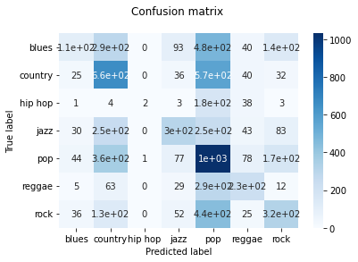

```python
import seaborn as sns
import matplotlib.pyplot as plt

from sklearn.metrics import confusion_matrix
from sklearn.utils.multiclass import unique_labels

cm = confusion_matrix(y_test, y_pred_SVC_o)

classes = unique_labels(y_test, y_pred_SVC_o)

df = pd.DataFrame(cm, index=classes, columns=classes)

g = sns.heatmap(df, annot=True, cmap="Blues")
g.set_yticklabels(g.get_yticklabels(), rotation=0)

plt.title('Confusion matrix \n')
plt.xlabel('Predicted label')
plt.ylabel('True label')

plt.autoscale()
```

La diagonal de matriz de confusión está solo ligeramente marcada y los valores de valores de precision, recall y F1 cercanos a solamente el 30-40%. Con respecto a la pregunta, hasta ahora, se puede concluir que los aspectos técnicos no son muy determinantes en su género.

### K-Fold Cross Validation

Se aplica una validación mediante la iteración de cross validation con un valor de k=4, esta entrega un valor de 0.31, similar a lo obtenido en los resultados previos, por lo que consideramos que confirma dichos valores.

```python
from sklearn.model_selection import train_test_split
from sklearn import svm
from sklearn.model_selection import KFold

kf = KFold(n_splits=4)
for train, test in kf.split(df_tecnico):
  clf = svm.SVC(kernel='linear', C=1).fit(X_over, y_over)
clf.score(X_test, y_test)
```

```
0.3159452981813055
```

### Segunda propuesta

Se parte filtrando solamente los atributo de genero y de lyrics

```python
import pandas as pd
import seaborn as sns
import matplotlib.pyplot as plt
from sklearn.metrics import confusion_matrix
from sklearn.utils.multiclass import unique_labels
import numpy as np
from sklearn.neighbors import KNeighborsClassifier
from sklearn.model_selection import train_test_split
from sklearn.tree import DecisionTreeClassifier
from sklearn.metrics import accuracy_score
from sklearn.metrics import classification_report
import requests
import re
import string
from sklearn.feature_extraction.text import CountVectorizer
df = pd.read_csv(r'C:\Users\benja\Desktop\Mineria de Datos\Hito 1\datos.csv')
df_lirico = df[['genre', 'lyrics']]
```

Debido a que la palabra genre se puede llegar a encontrar en las letras de las canciones, se renombra la columna correspondiente como GENRE_DF

```python
df_lirico.rename(columns = {'genre':'GENRE_DF'}, inplace = True)
```

Se vectorizan las letras de las canciones

```python
#Codigo obtenido de Laboratorio 2.1 del curso CC5205-2 Primavera 2022
def remove_numbers(text):
    text = re.sub(r"[0-9]", " ", text)
    return " ".join(text.split())


def remove_unprintable_(text):
    printable = set(string.printable + "ñáéíóúü" + "ÑÁÉÍÓÚÜ")
    text = "".join(filter(lambda x: x in printable, text))
    return text

def remove_punctuation(text):
    pattern = re.compile(r"[^\w\sáéíóúüñÁÉÍÓÚÜÑ]")
    t = pattern.sub(r" ", text)
    return re.sub(" +", " ", t)


def reduce_spam(text):
    text = re.sub(r"(\w+)(\s+\1){2,}", r"\1", text)
    text = re.sub(r"(\w+\s+\w+)(\s+\1){2,}", r"\1", text)
    return text


def remove_vowels_accents(text):
    return (
        text.replace("á", "a")
        .replace("é", "e")
        .replace("í", "i")
        .replace("ó", "o")
        .replace("ú", "u")
        .replace("ü", "u")
    )

def remove_stopwords(text, stopwords_list):
    return " ".join(
        [word for word in str(text).split() if word not in stopwords_list]
    )

url = "https://raw.githubusercontent.com/jorgeortizfuentes/spanish_nlp/main/utilities/stopwords_es.txt"
r = requests.get(url)

stopwords_list = r.text.splitlines()

def preprocesar(text):
    text = text.lower()
    text = remove_numbers(text)
    text = remove_unprintable_(text)
    text = remove_punctuation(text)
    text = reduce_spam(text)
    text = remove_stopwords(text, stopwords_list)
    text = remove_vowels_accents(text)
    return text.strip()


# Extraer los vectores
vectorizer = CountVectorizer(preprocessor=preprocesar, min_df=2)
vectors = vectorizer.fit_transform(df_lirico["lyrics"])

# Incorporar los vectores como dataframe
X = pd.DataFrame(vectors.toarray(), columns=vectorizer.get_feature_names())
y = df_lirico["GENRE_DF"]

df_vectorizado = pd.concat([y, X], axis=1)
df_vectorizado.head()
```

|  | GENRE_DF | aaaa | aaaaaa | aaaaaaa | aaaaaaaaaaah | aaaaah | aaaah | aaah | aaahhh | aaahhhh | ... | zombified | zona | zone | zonin | zookeeper | zoom | zoot | zoovie | zulu | zydeco |
| --- | --- | --- | --- | --- | --- | --- | --- | --- | --- | --- | --- | --- | --- | --- | --- | --- | --- | --- | --- | --- | --- |
| 0 | pop | 0 | 0 | 0 | 0 | 0 | 0 | 0 | 0 | 0 | ... | 0 | 0 | 0 | 0 | 0 | 0 | 0 | 0 | 0 | 0 |
| 1 | pop | 0 | 0 | 0 | 0 | 0 | 0 | 0 | 0 | 0 | ... | 0 | 0 | 0 | 0 | 0 | 0 | 0 | 0 | 0 | 0 |
| 2 | pop | 0 | 0 | 0 | 0 | 0 | 0 | 0 | 0 | 0 | ... | 0 | 0 | 0 | 0 | 0 | 0 | 0 | 0 | 0 | 0 |
| 3 | pop | 0 | 0 | 0 | 0 | 0 | 0 | 0 | 0 | 0 | ... | 0 | 0 | 0 | 0 | 0 | 0 | 0 | 0 | 0 | 0 |
| 4 | pop | 0 | 0 | 0 | 0 | 0 | 0 | 0 | 0 | 0 | ... | 0 | 0 | 0 | 0 | 0 | 0 | 0 | 0 | 0 | 0 |

5 rows × 22765 columns

Se hace la division de los datos en datos de entreno y datos de testing, tomando en este caso una proporcion 75/25. Luego se aplican metodos de subsampling y oversampling al conjunto de entreno con el fin de balancear los datos.

```python
X_train, X_test, y_train, y_test = train_test_split(df_vectorizado, y, test_size=0.25, stratify=y)
```

```python
#Partamos aplicando tecnicas de subsampling y oversampling
import numpy as np
#oversampling sobre el grupo de training
X_train = X_train.reset_index(drop=True)
idx = np.random.choice(X_train[X_train['GENRE_DF'] == "country"].index, size=1197)
data_oversampled = pd.concat([X_train, X_train.iloc[idx]])

idx = np.random.choice(X_train[X_train['GENRE_DF'] == "blues"].index, size=1828)
data_oversampled = pd.concat([data_oversampled, X_train.iloc[idx]])

idx = np.random.choice(X_train[X_train['GENRE_DF'] == "rock"].index, size=2256)
data_oversampled = pd.concat([data_oversampled, X_train.iloc[idx]])

idx = np.random.choice(X_train[X_train['GENRE_DF'] == "jazz"].index, size=2397)
data_oversampled = pd.concat([data_oversampled, X_train.iloc[idx]])

idx = np.random.choice(X_train[X_train['GENRE_DF'] == "reggae"].index, size=3407)
data_oversampled = pd.concat([data_oversampled, X_train.iloc[idx]])

idx = np.random.choice(X_train[X_train['GENRE_DF'] == "hip hop"].index, size=4603)
data_oversampled = pd.concat([data_oversampled, X_train.iloc[idx]])

print("Data oversampled on genre`s classes")
print(data_oversampled['GENRE_DF'].value_counts())
print()


#subsampling sobre el grupo de training

idx = np.random.choice(X_train.loc[X_train.GENRE_DF == "pop"].index, size=4603, replace=False)
data_subsampled = X_train.drop(X_train.iloc[idx].index)

idx = np.random.choice(X_train.loc[X_train.GENRE_DF == "country"].index, size=3406, replace=False)
data_subsampled = data_subsampled.drop(X_train.iloc[idx].index)

idx = np.random.choice(X_train.loc[X_train.GENRE_DF == "blues"].index, size=2775, replace=False)
data_subsampled = data_subsampled.drop(X_train.iloc[idx].index)

idx = np.random.choice(X_train.loc[X_train.GENRE_DF == "rock"].index, size=2347, replace=False)
data_subsampled = data_subsampled.drop(X_train.iloc[idx].index)

idx = np.random.choice(X_train.loc[X_train.GENRE_DF == "jazz"].index, size=2206, replace=False)
data_subsampled = data_subsampled.drop(X_train.iloc[idx].index)

idx = np.random.choice(X_train.loc[X_train.GENRE_DF == "reggae"].index, size=1196, replace=False)
data_subsampled = data_subsampled.drop(X_train.iloc[idx].index)
print("Data subsampled on genre`s classes")
print(data_subsampled['GENRE_DF'].value_counts())
```

```
Data oversampled on genre`s classes
pop        5282
rock       5281
jazz       5281
blues      5281
country    5281
hip hop    5281
reggae     5280
Name: GENRE_DF, dtype: int64

Data subsampled on genre`s classes
pop        679
rock       678
blues      678
jazz       678
country    678
hip hop    678
reggae     677
Name: GENRE_DF, dtype: int64
```

```python
#datos para testing
X_test = X_test[X_test.columns.difference(["GENRE_DF"])].values
y_test = y_test
```

```python
#datos para training "originales"
X_train = X_train[X_train.columns.difference(["GENRE_DF"])].values
y_train = y_train
```

```python
# datos entrenamiento "oversampleados"
X_over = data_oversampled[data_oversampled.columns.difference(["GENRE_DF"])].values
y_over = data_oversampled["GENRE_DF"].values
```

```python
# datos entrenamiento "subsampleados"
X_subs = data_subsampled[data_subsampled.columns.difference(["GENRE_DF"])].values
y_subs = data_subsampled["GENRE_DF"].values
```

Debido a la magnitud de los datos, resulta imposible aplicar metodos para encontrar los hiperparametros mas optimos, por lo que se decide ocupar los algoritmos de clasificacion con los hiperparamteros por defecto

A continuacion se aplican modelos de DecisionTreeClassifier, GaussianNB y KNeighbors sobre los 3 conjuntos generados(original, subsampling y oversampling). Este procedimiento es el mismo al realizado en la pregunta 1, por lo que solamente entregaremos el modelo mas optimo encontrado, para asi generar un codigo mas limpio

Decision Tree

```python
#Datos oversampleados
clf2 = DecisionTreeClassifier()
clf2.fit(X_over, y_over)
y_pred_over = clf2.predict(X_test)
print("Accuracy:", accuracy_score(y_test, y_pred_over))
print(classification_report(y_test, y_pred_over))
```

```
Accuracy: 0.26674185817002677
              precision    recall  f1-score   support

       blues       0.22      0.25      0.23      1151
     country       0.31      0.31      0.31      1361
     hip hop       0.43      0.47      0.45       226
        jazz       0.24      0.24      0.24       961
         pop       0.27      0.27      0.27      1760
      reggae       0.27      0.25      0.26       625
        rock       0.24      0.22      0.23      1009

    accuracy                           0.27      7093
   macro avg       0.28      0.29      0.28      7093
weighted avg       0.27      0.27      0.27      7093
```

En este caso el clasificador mas optimo resulta ser DecisionTree al ser utilizado sobre los datos oversampleados, a continuacion se presenta la matriz de confusion correspondiente a este modelo de clasificacion

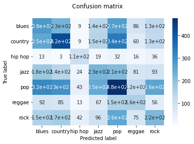

```python
cm = confusion_matrix(y_test, y_pred_over)

classes = unique_labels(y_test, y_pred_over)

df = pd.DataFrame(cm, index=classes, columns=classes)

g = sns.heatmap(df, annot=True, cmap="Blues")
g.set_yticklabels(g.get_yticklabels(), rotation=0)

plt.title('Confusion matrix \n')
plt.xlabel('Predicted label')
plt.ylabel('True label')

plt.autoscale()
```

Los resultados obtenidos del modelo mas preciso resultan ser poco optimos para poder dar una respuesta concluyente con respecto a la pregunta generada. Por este motivo se realiza un nuevo analisis, esta vez tomando una menor cantidad de atributos, buscando disminuir asi la dimensionalidad del problema

A continuacion se presenta un modelo clasificador basado en las letras de las canciones, pero especificamente se tomaran las 5 palabras mas repetidas por genero de cancion. A continuacion se detalla el desarrollo

Se parte obteniendo una lista con las palabras mas repetidas en cada genero

```python
final_lyrics=["GENRE_DF"]
for i in df_lirico.GENRE_DF.unique():
    copy = df_lirico[(df_lirico.GENRE_DF==i)]
    new_lyrics=pd.Series(' '.join(copy['lyrics']).split()).value_counts()[:5].index.tolist()
    for i in new_lyrics:
        if(i not in final_lyrics):
            final_lyrics.append(i)
```

```python
df_5_song=df_vectorizado[final_lyrics]
df_5_lyrics= df_5_song[final_lyrics[1:]] != 0
df_5_genre= df_5_song[final_lyrics[0]] == 0
df_iterator=pd.concat([df_5_genre, df_5_lyrics], axis=1)
df_5_song.loc[(df_iterator).any(1)]
```

|  | GENRE_DF | know | like | time | come | yeah | heart | baby | life | away | cause | nigga |
| --- | --- | --- | --- | --- | --- | --- | --- | --- | --- | --- | --- | --- |
| 0 | pop | 2 | 2 | 2 | 0 | 0 | 3 | 0 | 0 | 0 | 0 | 0 |
| 1 | pop | 1 | 0 | 1 | 1 | 0 | 0 | 1 | 0 | 0 | 0 | 0 |
| 3 | pop | 0 | 2 | 0 | 2 | 0 | 1 | 0 | 0 | 1 | 0 | 0 |
| 4 | pop | 4 | 0 | 2 | 0 | 0 | 0 | 0 | 0 | 0 | 0 | 0 |
| 5 | pop | 0 | 1 | 0 | 0 | 0 | 0 | 0 | 0 | 0 | 0 | 0 |
| ... | ... | ... | ... | ... | ... | ... | ... | ... | ... | ... | ... | ... |
| 28367 | hip hop | 0 | 1 | 0 | 1 | 0 | 0 | 0 | 0 | 0 | 2 | 0 |
| 28368 | hip hop | 2 | 1 | 0 | 1 | 0 | 0 | 0 | 1 | 0 | 0 | 3 |
| 28369 | hip hop | 1 | 1 | 0 | 1 | 0 | 0 | 0 | 0 | 0 | 0 | 0 |
| 28370 | hip hop | 0 | 2 | 0 | 0 | 2 | 0 | 0 | 0 | 0 | 0 | 0 |
| 28371 | hip hop | 1 | 3 | 0 | 0 | 0 | 0 | 0 | 0 | 0 | 2 | 1 |

26265 rows × 12 columns

Para poder determinar si es que un modelo con estos atributos sirve o no, se ocupara el modelo mas preciso obtenido en la parte anterior, es decir, DecisionTree Classifier

```python
#Probemos el modelo mas optimo anterior, tomando ahora solamente las 5 letras mas repetidas por cada cancion
clf = DecisionTreeClassifier()
X= df_5_song[df_5_song.columns.difference(["GENRE_DF"])].values
y=df_5_song["GENRE_DF"]
X_train, X_test, y_train, y_test = train_test_split(X, y, test_size=0.25, stratify=y)
```

Se calculan los parametros de rendimiento

```python
clf.fit(X_train, y_train)
y_pred = clf.predict(X_test)
print("Accuracy:", accuracy_score(y_test, y_pred))
print(classification_report(y_test, y_pred))
```

```
Accuracy: 0.20978429437473564
              precision    recall  f1-score   support

       blues       0.18      0.19      0.18      1151
     country       0.26      0.25      0.25      1361
     hip hop       0.15      0.14      0.14       226
        jazz       0.17      0.14      0.15       961
         pop       0.25      0.35      0.29      1761
      reggae       0.12      0.08      0.09       625
        rock       0.15      0.10      0.12      1008

    accuracy                           0.21      7093
   macro avg       0.18      0.18      0.18      7093
weighted avg       0.20      0.21      0.20      7093
```

Se obtiene la matriz de confusion correspondiente

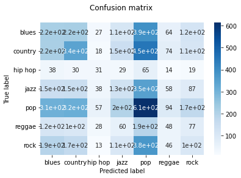

```python
cm = confusion_matrix(y_test, y_pred)

classes = unique_labels(y_test, y_pred)

df = pd.DataFrame(cm, index=classes, columns=classes)

g = sns.heatmap(df, annot=True, cmap="Blues")
g.set_yticklabels(g.get_yticklabels(), rotation=0)

plt.title('Confusion matrix \n')
plt.xlabel('Predicted label')
plt.ylabel('True label')

plt.autoscale()
```

Los resultado siguen siendo malos, por lo que se aplicara una logica mas simple. Actualmente se esta generando un modelo que intenta predecir el tipo de genero dado su letra, pero el modelo puede optar por 7 distintas opciones para elegir. Con el fin de obtener un modelo de clasificacion que entregue informacion relativamente precisa, generaremos un nuevo modelo que busque identificar solamente entre 2 generos en particulas, para esto se ocupara el genero con las palabras mas distintas(hiphop) y el genero que mas diverga con este.

De antemano se sabe que el hip hop es el genero con mas palabras diversas, teniendo esto en consideracion se buscara encontrar el genero que tenga menos palabras en comun con el hip hop, determinando a este como el genero que mas diverge

```python
#Consideramos que hip hop es el genero con mas palabras distinta,
#busquemos ahora cual es el genero que ams se diferencia de este
#Para esto consultaremos las palabras de cada genero y las compararemos con las palabras de hip hop

genre=""
min_genre=10e9
hiphop_list=pd.Series(' '.join(df_lirico[(df_lirico.GENRE_DF=="hip hop")]['lyrics']).split()).value_counts().index.tolist()
for i in df_lirico.GENRE_DF.unique():
    copy = df_lirico[(df_lirico.GENRE_DF==i)]
    new_list=pd.Series(' '.join(copy['lyrics']).split()).value_counts().index.tolist()
    second_counter=0
    for j in new_list:
        if j in hiphop_list:
            second_counter+=1
    if(second_counter<=min_genre):
        genre=i
        min_genre=second_counter
print(genre,min_genre)
```

```
country 5740
```

Luego country es el genero menos parecido a hip hop, en cuanto a letras de las canciones se refiere

Se genera un dataframe que solamente posea estos dos generos

```python
#Unamos estos dos generos en un solo dataframe
df_two=df_vectorizado[(df_vectorizado['GENRE_DF'] == 'hip hop') | (df_vectorizado['GENRE_DF'] == 'country')].copy()
df_two["GENRE_DF"].value_counts()
```

```
country    5445
hip hop     904
Name: GENRE_DF, dtype: int64
```

Es facil darse cuenta que los datos se encuentra desbalanceados por lo que aplicaremos subsampling y oversampling a los datos, para luego aplicar modelos sobre estos con el fin de comparar y encontrar el modelo mas optimo.

```python
X_train, X_test, y_train, y_test = train_test_split(df_two, df_two["GENRE_DF"], test_size=0.25, stratify=df_two["GENRE_DF"])
y_train.value_counts()
```

```
country    4083
hip hop     678
Name: GENRE_DF, dtype: int64
```

```python
#Partamos aplicando tecnicas de subsampling y oversampling
import numpy as np
#oversampling sobre el grupo de training
X_train = X_train.reset_index(drop=True)
idx = np.random.choice(X_train[X_train['GENRE_DF'] == "hip hop"].index, size=3405)
data_oversampled = pd.concat([X_train, X_train.iloc[idx]])

print("Data oversampled on genre`s classes")
print(data_oversampled['GENRE_DF'].value_counts())
print()

#subsampling sobre el grupo de training

idx = np.random.choice(X_train.loc[X_train.GENRE_DF == "country"].index, size=3405, replace=False)
data_subsampled = X_train.drop(X_train.iloc[idx].index)

print("Data subsampled on genre`s classes")
print(data_subsampled['GENRE_DF'].value_counts())
```

```
Data oversampled on genre`s classes
hip hop    4083
country    4083
Name: GENRE_DF, dtype: int64

Data subsampled on genre`s classes
hip hop    678
country    678
Name: GENRE_DF, dtype: int64
```

```python
# datos para testing
X_test = X_test[X_test.columns.difference(["GENRE_DF"])].values
y_test = y_test

# datos entrenamiento "originales"
X_train = X_train[X_train.columns.difference(["GENRE_DF"])].values
y_train = y_train

# datos entrenamiento "oversampleados"
X_over = data_oversampled[data_oversampled.columns.difference(["GENRE_DF"])].values
y_over = data_oversampled["GENRE_DF"].values

# datos entrenamiento "subsampleados"
X_subs = data_subsampled[data_subsampled.columns.difference(["GENRE_DF"])].values
y_subs = data_subsampled["GENRE_DF"].values
```

Se aplicaran ahora los 3 modelos de clasificacion, siendo estos DecisionTree, KNeighbors y GaussianNB. Este procedimiento conlleva el mismo procedimiento que el realizado para resolver la pregunta 1, por lo que este se omitira para evitar mayor confusion de codigo, y simplemten se entregara el modelo mas preciso.

DecisionTreeClassifier

```python
clf = DecisionTreeClassifier()
clf.fit(X_train, y_train)
y_pred_original_decision = clf.predict(X_test)
print("Original data")
print("Accuracy:", accuracy_score(y_test, y_pred_original_decision))
print(classification_report(y_test, y_pred_original_decision))
```

```
Original data
Accuracy: 0.9332493702770781
              precision    recall  f1-score   support

     country       0.96      0.97      0.96      1362
     hip hop       0.78      0.74      0.76       226

    accuracy                           0.93      1588
   macro avg       0.87      0.85      0.86      1588
weighted avg       0.93      0.93      0.93      1588
```

El modelo mas preciso resulta ser el DecisionTree utilizado sobre los datos originales, obteniendo aproximadamente un 93,5% de precision.

Luego su matriz de confusion es la siguiente

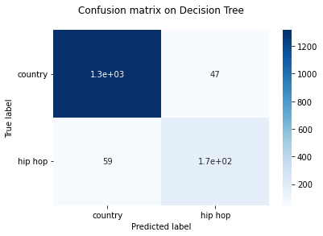

```python
import seaborn as sns
import matplotlib.pyplot as plt

from sklearn.metrics import confusion_matrix
from sklearn.utils.multiclass import unique_labels
cm = confusion_matrix(y_test, y_pred_original_decision)

# Only use the labels that appear in the data
classes = unique_labels(y_test, y_pred_original_decision)

df = pd.DataFrame(cm, index=classes, columns=classes)

g = sns.heatmap(df, annot=True, cmap="Blues")
g.set_yticklabels(g.get_yticklabels(), rotation=0)

plt.title('Confusion matrix on Decision Tree\n')
plt.xlabel('Predicted label')
plt.ylabel('True label')

plt.autoscale()
```

Se puede notar que esta matriz se encuentra bien distribuida, donde en la diagonal de la matriz se encuentra la mayor concentracion de datos, es decir datos correctamente clasificados. Luego se tiene un modelo de clasificacion que dado dos generos opuestos, puede determinar un genero de otro utilizando las letras de las canciones

Se concluye que los algoritmos de clasificacion son incapaces de catalogar todos los generos mediante el uso exclusivo de las letras de las canciones. Pero por otro lado se pudo llegar a resultados favorables en cuanto se refiere a algoritmos de clasificacion que determinen el genero de una canciones usando la letra con un conjunto de "recorrido" de 2 generos opuestos. Luego se puede decir que existen ciertos generos musicales con liricas mas marcadas que otros tal que estas pueden ser reconocidas al ser comparadas con las liricas de otro genero, aun asi, cabe destacar que al tener un mayor numero de generos para llevar a cabo una comparacion, las liricas especiales de cada genero pasan a ser un aspecto dificil de diferenciar en cuanto al genero se refiere.

### Tercera propuesta

Se filtran los atributos, dejando aquellos que representan cómo suena una canción.

```python
df = pd.read_csv(r'C:\Users\benja\Desktop\Mineria de Datos\Hito 1\datos.csv')
X=df[['danceability', 'loudness', 'acousticness', 'instrumentalness', 'valence', 'energy']]
X.head()
```

|  | danceability | loudness | acousticness | instrumentalness | valence | energy |
| --- | --- | --- | --- | --- | --- | --- |
| 0 | 0.357739 | 0.454119 | 0.997992 | 0.901822 | 0.339448 | 0.137110 |
| 1 | 0.331745 | 0.647540 | 0.954819 | 0.000002 | 0.325021 | 0.263240 |
| 2 | 0.456298 | 0.585288 | 0.840361 | 0.000000 | 0.351814 | 0.139112 |
| 3 | 0.686992 | 0.744404 | 0.083935 | 0.199393 | 0.775350 | 0.743736 |
| 4 | 0.291671 | 0.646489 | 0.975904 | 0.000246 | 0.597073 | 0.394375 |

### Agrupaciones según etiqueta

En primer lugar, se pueden visualizar los 7 clusters que generaría un modelo perfecto que agrupa canciones según sus géneros, con la técnica PCA. Luego, al aplicar los distintos modelos de clustering sobre la data no etiquetada, se esperaría obtener una distribución similar a la mostrada a continuación.

```python
dicc={"pop":0,"country":1,"blues":2,"jazz":3,"reggae":4,"rock":5,"hip hop":6}
values=df["genre"].copy().to_numpy()
for i in range (0, len(values)):
  values[i] = dicc[values[i]]
```

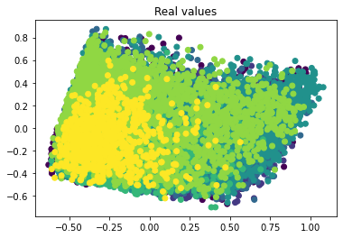

```python
from sklearn.decomposition import PCA
import matplotlib.pyplot as plt

pca = PCA(n_components=2).fit(X)
new_X = pca.transform(X)

plt.scatter(new_X[:, 0], new_X[:, 1], c=values)
plt.title("Real values")
plt.show()
```

### K-means

Como se sugirió en la retroalimentación, sería interesante primero estudiar si realmente la cantidad de clusters debiese ser igual a la cantidad de géneros, pues podría eventualmente existir otra agrupación natural de las canciones. Para ello, se utiliza el método del codo.

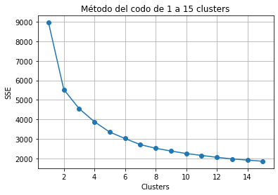

```python
from sklearn.cluster import KMeans

sse = []
clusters = list(range(1, 16))
for k in clusters:
    kmeans = KMeans(n_clusters=k).fit(X)
    sse.append(kmeans.inertia_)

plt.plot(clusters, sse, marker="o")
plt.title("Método del codo de 1 a 15 clusters")
plt.xlabel("Clusters")
plt.ylabel("SSE")
plt.grid(True)
plt.show()
```

```python
kmeans1 = KMeans(n_clusters=7, n_init=10, max_iter=300)
kmeans1.fit(X)
kmeans1.labels_
```

```
array([6, 2, 2, ..., 0, 0, 5])
```

Se obtiene la asignación de cada canción según el modelo de clustering.

```python
df_labeled = df['genre'].copy().to_frame()
df_labeled['cluster_id'] = kmeans1.labels_
df_labeled.head()
```

|  | genre | cluster_id |
| --- | --- | --- |
| 0 | pop | 6 |
| 1 | pop | 2 |
| 2 | pop | 2 |
| 3 | pop | 0 |
| 4 | pop | 2 |

A continuación se muestra la proporción de asignación de canciones a cada cluster, por cada género.

```python
for genre in ['blues', 'country', 'hip hop', 'jazz', 'pop', 'reggae', 'rock']:
  df_genre = df_labeled[df_labeled['genre'] == genre] # Filtrar por género
  df_grouped = df_genre.groupby(['cluster_id']) # Agrupar por cluster
  print('Cantidad de canciones en ' + genre + ': ' + str(len(df_genre)))
  print(round(df_grouped.count()/len(df_genre), 3))
  print('\n')
```

```
Cantidad de canciones en blues: 4604
            genre
cluster_id
0           0.209
1           0.199
2           0.165
3           0.075
4           0.208
5           0.124
6           0.020


Cantidad de canciones en country: 5445
            genre
cluster_id
0           0.213
1           0.229
2           0.265
3           0.005
4           0.086
5           0.194
6           0.009


Cantidad de canciones en hip hop: 904
            genre
cluster_id
0           0.617
1           0.069
2           0.003
3           0.013
4           0.153
5           0.143
6           0.002


Cantidad de canciones en jazz: 3845
            genre
cluster_id
0           0.153
```

[output cut: 27 more lines]

```
4           0.078
5           0.107
6           0.005


Cantidad de canciones en rock: 4034
            genre
cluster_id
0           0.180
1           0.069
2           0.096
3           0.084
4           0.432
5           0.127
6           0.012
```

De lo anterior se desprende lo siguiente:

- Las canciones de blues, hip hop, pop y reggae tienden a irse al mismo cluster.
- Las canciones de country y jazz tienden irse a otro cluster.
- Las canciones de rock tienden a irse a un cluster aparte.

Claramente los resultados anteriores no son definitivos, pues las distribuciones no tienen una preferencia concreta por un cluster y hay clusters con muy pocas canciones de todos los géneros. Recordando que la probabilidad de asignación aleatoria a un género dado es 0,14, se podría decir que algunas agrupaciones sí son sensatas.

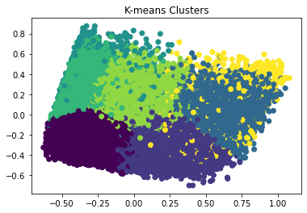

```python
plt.scatter(new_X[:, 0], new_X[:, 1], c=kmeans1.labels_)
plt.title("K-means Clusters")
plt.show()
```

Finalmente, si se grafican los clusters y comparan con la distribución original es claro que los clusters generados no replican la asignación manual de géneros.

Dado que el resultado anterior no es del todo satisfactorio, se podría estudiar si canciones de solamente dos géneros son separables. Se pueden considerar solamente jazz y rock, pues son géneros que son intuitivamente distintos en cómo suenan, tendían a irse a clusters distintos en el modelo anterior y además tendían a no irse al cluster del otro, es decir, en el cluster asociado al rock no calzaron muchas canciones de jazz y viceversa.

```python
df_filtrado = df[(df['genre'] == 'jazz') | (df['genre'] == 'rock')].copy()
X_filtrado = df_filtrado[['danceability', 'loudness', 'acousticness', 'instrumentalness', 'valence', 'energy']]
kmeansf = KMeans(n_clusters=2, n_init=10, max_iter=300)
kmeansf.fit(X_filtrado)
kmeansf.labels_
```

```
array([1, 1, 1, ..., 0, 0, 0])
```

```python
df_labeled_filtrado = df_filtrado['genre'].copy().to_frame()
df_labeled_filtrado['cluster_id'] = kmeansf.labels_
df_labeled_filtrado
```

|  | genre | cluster_id |
| --- | --- | --- |
| 17091 | jazz | 1 |
| 17092 | jazz | 1 |
| 17093 | jazz | 1 |
| 17094 | jazz | 1 |
| 17095 | jazz | 1 |
| ... | ... | ... |
| 27463 | rock | 0 |
| 27464 | rock | 0 |
| 27465 | rock | 0 |
| 27466 | rock | 0 |
| 27467 | rock | 0 |

7879 rows × 2 columns

```python
for genre in ['jazz', 'rock']:
  df_genre_filtrado = df_labeled_filtrado[df_labeled_filtrado['genre'] == genre] # Filtrar por género
  df_grouped_filtrado = df_genre_filtrado.groupby(['cluster_id']) # Agrupar por cluster
  print('Cantidad de canciones en ' + genre + ': ' + str(len(df_genre_filtrado)))
  print(round(df_grouped_filtrado.count()/len(df_genre_filtrado), 3))
  print('\n')
```

```
Cantidad de canciones en jazz: 3845
            genre
cluster_id
0           0.446
1           0.554


Cantidad de canciones en rock: 4034
            genre
cluster_id
0           0.814
1           0.186
```

Si se observa la asignación de clusters, se podría sin ambigüedad decir que hay un cluster que se puede asociar a canciones de jazz y que el otro cluster se puede asociar a las de rock. Sin embargo, la agrupación generada es tal que el cluster asociado al rock captura muchísimas de las canciones de rock (aproximadamente el 80%) y al mismo tiempo una gran cantidad de las de jazz (aproximadamente el 44%), mientras que el cluster asociado al jazz captura una gran cantidad de las de jazz y pocas de las de rock. Es decir, el cluster asociado al jazz es más selectivo para el género jazz que el cluster asociado al rock lo es para el género rock. Se concluye entonces que el modelo generado captura la diferencia que rock tiene del jazz, pero no muy bien la inferencia que se haría sobre una canción de jazz.

### DBSCAN

Para ejecutar el algoritmo DBSCAN, se deben escoger los parámetros min_samples y eps. El segundo parámetro se puede estimar a partir del primero con el método de la rodilla. Por lo tanto, se exploran distintos valores para min_samples y ejecuta DBSCAN para ver si la cantidad de clusters generada es razonable. Con un valor muy grande se obtenían muy pocos clusters y con un valor muy pequeño se obtenían muchísimos clusters. El valor intermedio escogido es entonces min_samples = 10.

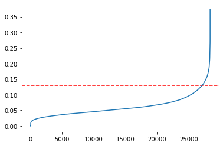

```python
from sklearn.neighbors import NearestNeighbors
import numpy as np

N = 10 #corresponde a 'min_samples'

nbrs = NearestNeighbors(n_neighbors=N).fit(X)
distances, indices = nbrs.kneighbors(X)

distances = np.sort(distances, axis=0)
distances = distances[:,1]
plt.axhline(y=0.13, color='r', linestyle='--') #Ajuste el valor para y
plt.plot(distances);
```

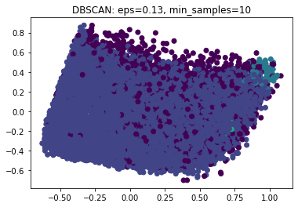

```python
from sklearn.cluster import DBSCAN

eps = 0.13
min_samples = 10

dbscan2 = DBSCAN(eps=eps, min_samples=min_samples).fit(X)
plt.scatter(new_X[:,0], new_X[:,1], c=dbscan2.labels_)
plt.title(f"DBSCAN: eps={eps}, min_samples={N}")
plt.show()
```

```python
np.unique(dbscan2.labels_)
```

```
array([-1,  0,  1,  2,  3,  4], dtype=int64)
```

El problema es que este valor no representa una cantidad razonable con respecto a la distribución original de canciones entre los 7 géneros, y debiese ser un valor en el orden de las centenas o miles (un género con 10 canciones no es un género). Además, visualmente se observan muchísimos outliers, lo que no provee utilidad. Se concluye que quizás un método por densidad no es apropiado para este conjunto de datos debido a su dispersión en el espacio de atributos.

### Jerárquico

Para decidir el punto de corte en el clustering jerárquico de tipo aglomerativo, se genera el dendrogama correspondiente. Se corta en 20 para obtener 7 clusters.

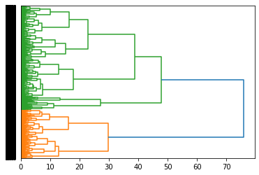

```python
from scipy.cluster.hierarchy import dendrogram, linkage

Z = linkage(X, 'ward', metric='euclidean')
dn = dendrogram(Z, orientation='right')
```

```python
from sklearn.cluster import AgglomerativeClustering

complete_all2 = AgglomerativeClustering(linkage="ward",
                                       affinity='euclidean',
                                       n_clusters=None,
                                       distance_threshold=20).fit(X)
```

Al graficar los clusters generados por el clustering aglomerativo, se obtiene nuevamente una distribución que no coincide con los valores reales.

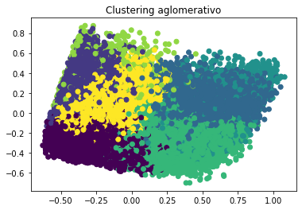

```python
plt.scatter(new_X[:,0], new_X[:,1], c=complete_all2.labels_)
plt.title('Clustering aglomerativo')
plt.show()
```

Se concluye que los algoritmos de clustering son incapaces de replicar la asignación manual de géneros. En este proyecto solamente se evaluó de manera externa porque es lo que interesaba estudiar, pero sí es posible que existan agrupaciones naturales y estas eventualmente se podrían estudiar en otra oportunidad y ser evaluadas con otros métodos de validación interna como matriz de similitud o Silhouette. Lo anterior fundamenta el hecho de que quizás la forma de asociación manual de géneros (es decir, el proceso humano de considerar a varias canciones como similares y agruparlas en un género) tiene varios aspectos no matemáticos. Sería posible entonces que canciones que tienen país de origen similar o provienen de un mismo artista tiendan a agruparse en géneros similares cuando el sonido no sea similar. Otra posibilidad es que las canciones tienen una complejidad mucho más grande que solo los aspectos técnicos escogidos; por ejemplo, es posible que la presencia y reconocimiento de un instrumento en particular por un ser humano induzca a que una canción se clasifique de cierto género cuando hay varios otros aspectos que indican que sea otro género.

## 6. Conclusiones y planificación futura

En el escenario en que se contase con más tiempo para continuar el desarrollo de este proyecto, el curso de acción que se tomaría sería probar con otras combinaciones de atributos buscando correlaciones entre ellas. También se buscarían más datasets sobre este tema que puedan incluir atributos nuevos útiles, con el propósito de una exploración más a fondo con tal de complementar la información a estudiar. Además, en específico para el problema de clustering, sería interesante seguir estudiando los clusters generados con validación interna, pues en este proyecto solo se consideró si se replican las etiquetas conocidas y se podría estudiar qué tan buenas son las agrupaciones naturales de los datos, si las hay.

A modo de recomendaciones a futuras personas que deseasen abordar este problema, se sugiere indagar más en los atributos temáticos incluídos en la base de datos, los cuales describen los asuntos tratados en las letras de las canciones, por lo cual se puede encontrar en ellos una mejor descripción emocional de éstas. Algunos de estos atributos corresponden a "violence", "romance", "world/life", etc. Así, se puede ver cómo estos valores numéricos asociados a cada temática representan de qué se habla en las canciones y se puede identificar un vínculo emocional más claro. Además, se encuentra el atributo "topic", el cual muestra el tema principal tratado en cada canción, por lo que se podría estudiar qué tópicos son más abordados en cada género musical.

## 7. Contribuciones de integrantes (Hito 3)

- Exploración de datos: Benjamin Alvial
- Redacción de preguntas y problemas: Benjamín Aguilar y Benjamín Alvial
- Desarrollo de primera propuesta experimental: Benjamin Aguilar y Diego Reyes
- Desarrollo de segunda propuesta experimental: Benjamin Aguilar
- Desarrollo de tercera propuesta experimental: Benjamin Alvial
- Redacción de conclusiones y planificación futura: Jules Fredes C.
- Diseño de diapositivas: Jules Fredes C.
- Edición y correción: Diego Carmona